# Caso práctico 4: Generación de mapas de precipitación mediante técnicas de krigeado

Predicción kriging usando la librería ‘geoR’

#### Install packages.

```r
# install.packages("maptools")
# install.packages("rgdal")
# install.packages("raster")
# install.packages("classInt")
# install.packages("RColorBrewer")
# install.packages("geoR")
# install.packages("rgeos")
```

#### Load packages.

```r
library(maptools)
library(rgdal)
library(raster)
library(classInt)
library(RColorBrewer)
library(geoR)
library(rgeos)
```

#### Set working directory

Note that in R the bar of a path is /, while in Windows it is the counterbar.

```r
setwd("../caso_practico_4/")
```

#### Loading the observations

Loading the shape point file which contains the observed data.

```r
dat <- readShapePoints("Datos_cp4/precip_seasonal.shp")
str(dat)
```

```
## Formal class 'SpatialPointsDataFrame' [package "sp"] with 5 slots
##   ..@ data       :'data.frame':  212 obs. of  16 variables:
##   .. ..$ INDICATIU : Factor w/ 212 levels "E7029","E7031",..: 1 2 3 4 5 6 7 8 9 10 ...
##   .. ..$ ESTACIO   : Factor w/ 212 levels "AGOST  ESCUELA NACIONAL",..: 173 125 143 109 20 108 93 101 163 80 ...
##   .. ..$ ALTITUD   : int [1:212] 203 2 45 1 40 2 60 502 36 90 ...
##   .. ..$ X         : num [1:212] 680954 693537 695385 701067 695181 ...
##   .. ..$ Y         : num [1:212] 4195707 4184490 4195298 4205830 4211023 ...
##   .. ..$ PROVINCIA : Factor w/ 8 levels "ALBACETE","ALICANTE",..: 5 5 2 2 2 2 2 5 5 5 ...
##   .. ..$ MesosCompl: int [1:212] 549 552 343 552 401 550 402 451 551 477 ...
##   .. ..$ MesosNoCom: int [1:212] 3 0 209 0 151 2 150 101 1 75 ...
##   .. ..$ AnysComple: int [1:212] 43 46 22 46 31 44 28 35 45 36 ...
##   .. ..$ AnysIncomp: int [1:212] 3 0 9 0 4 2 7 3 1 6 ...
##   .. ..$ AnysBuits : int [1:212] 0 0 15 0 11 0 11 8 0 4 ...
##   .. ..$ spring    : num [1:212] 78.9 76.5 74.7 61.9 80 ...
##   .. ..$ summer    : num [1:212] 25 23.8 20.6 17.7 19.8 ...
##   .. ..$ autumn    : num [1:212] 99.6 119.7 109.3 101.6 116.7 ...
##   .. ..$ winter    : num [1:212] 83.6 93.9 89.9 75.4 85 ...
##   .. ..$ annual    : num [1:212] 287 314 295 257 301 ...
##   .. ..- attr(*, "data_types")= chr [1:16] "C" "C" "N" "F" ...
##   ..@ coords.nrs : num(0)
##   ..@ coords     : num [1:212, 1:2] 680954 693537 695385 701067 695181 ...
##   .. ..- attr(*, "dimnames")=List of 2
##   .. .. ..$ : chr [1:212] "0" "1" "2" "3" ...
##   .. .. ..$ : chr [1:2] "coords.x1" "coords.x2"
##   ..@ bbox       : num [1:2, 1:2] 603884 4184490 814056 4532311
##   .. ..- attr(*, "dimnames")=List of 2
##   .. .. ..$ : chr [1:2] "coords.x1" "coords.x2"
##   .. .. ..$ : chr [1:2] "min" "max"
##   ..@ proj4string:Formal class 'CRS' [package "sp"] with 1 slot
##   .. .. ..@ projargs: chr NA
```

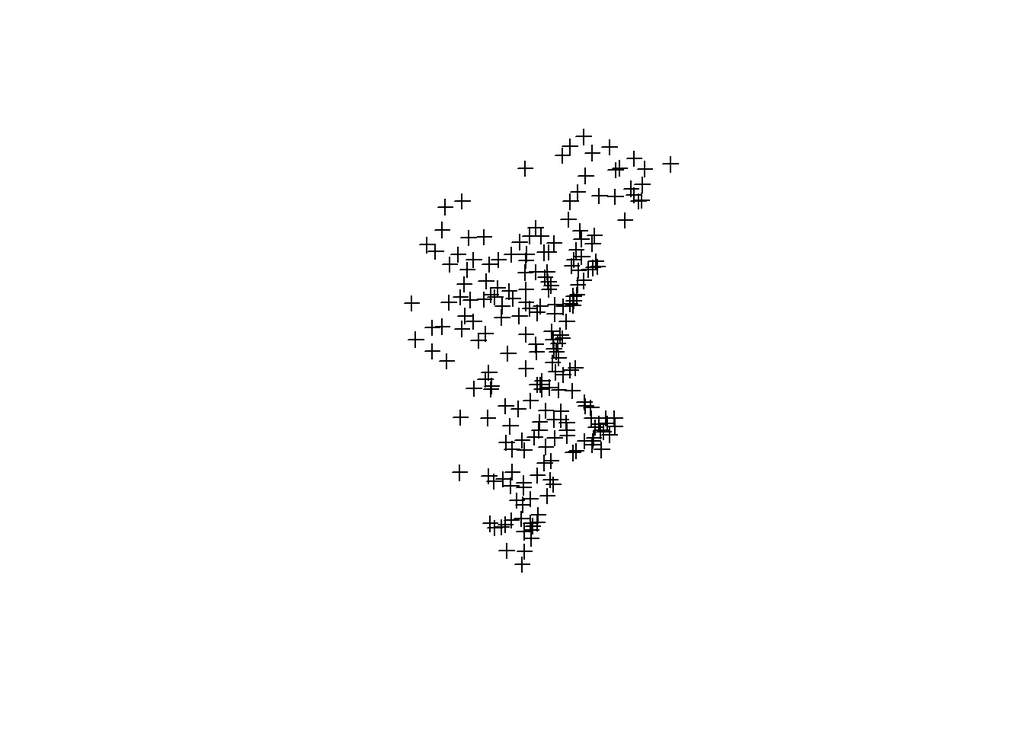

```r
plot(dat)
```

#### Loading the Valencian Community (VC) administrative boundaries

Loading the shape polygons file which contains the border of the Valencian Community.

```r
lim_cv <- readShapePoly("Datos_cp4/cv.shp")
str(lim_cv)
```

```
## Formal class 'SpatialPolygonsDataFrame' [package "sp"] with 5 slots
##   ..@ data       :'data.frame':  1 obs. of  1 variable:
##   .. ..$ PROVIN_ID: int 1
##   .. ..- attr(*, "data_types")= chr "N"
##   ..@ polygons   :List of 1
##   .. ..$ :Formal class 'Polygons' [package "sp"] with 5 slots
##   .. .. .. ..@ Polygons :List of 2
##   .. .. .. .. ..$ :Formal class 'Polygon' [package "sp"] with 5 slots
##   .. .. .. .. .. .. ..@ labpt  : num [1:2] 647997 4437991
##   .. .. .. .. .. .. ..@ area   : num 3.7e+08
##   .. .. .. .. .. .. ..@ hole   : logi FALSE
##   .. .. .. .. .. .. ..@ ringDir: int 1
##   .. .. .. .. .. .. ..@ coords : num [1:201, 1:2] 647805 648974 649215 649557 649612 ...
##   .. .. .. .. ..$ :Formal class 'Polygon' [package "sp"] with 5 slots
##   .. .. .. .. .. .. ..@ labpt  : num [1:2] 711404 4362427
##   .. .. .. .. .. .. ..@ area   : num 2.29e+10
##   .. .. .. .. .. .. ..@ hole   : logi FALSE
##   .. .. .. .. .. .. ..@ ringDir: int 1
##   .. .. .. .. .. .. ..@ coords : num [1:3291, 1:2] 741050 740996 740864 740933 741112 ...
##   .. .. .. ..@ plotOrder: int [1:2] 2 1
##   .. .. .. ..@ labpt    : num [1:2] 711404 4362427
##   .. .. .. ..@ ID       : chr "0"
##   .. .. .. ..@ area     : num 2.33e+10
##   ..@ plotOrder  : int 1
##   ..@ bbox       : num [1:2, 1:2] 626680 4191040 797835 4519371
##   .. ..- attr(*, "dimnames")=List of 2
##   .. .. ..$ : chr [1:2] "x" "y"
##   .. .. ..$ : chr [1:2] "min" "max"
##   ..@ proj4string:Formal class 'CRS' [package "sp"] with 1 slot
##   .. .. ..@ projargs: chr NA
```

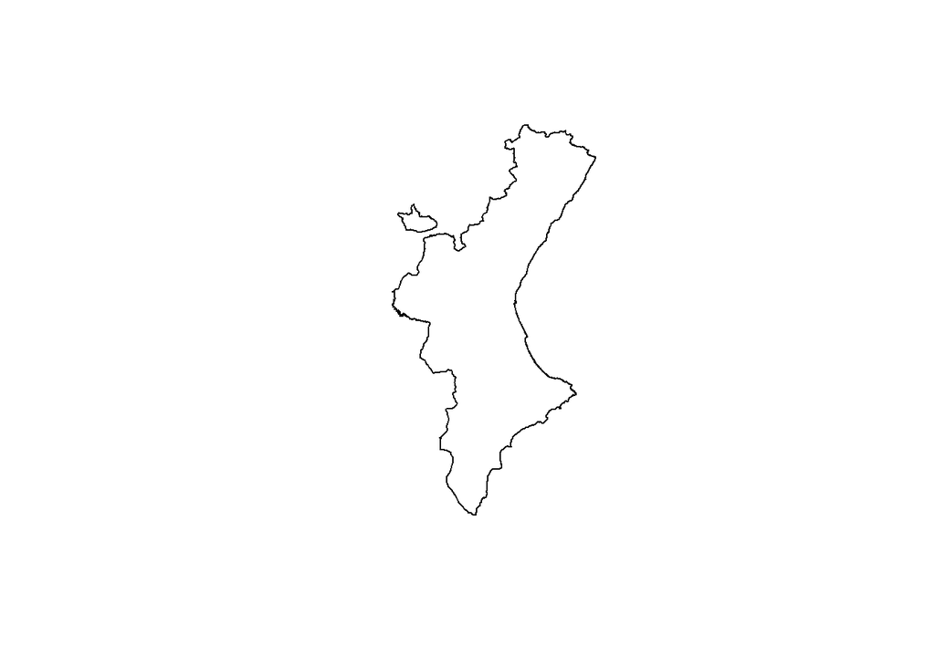

```r
plot(lim_cv)
```

#### Loading the raster file with the Digital Elevation Model (DEM)

Reading the raster file which contains DEM.

```r
ras <- raster("Datos_cp4/mde_100.tif", layer=0, values=TRUE)
str(ras)
```

```
## Formal class 'RasterLayer' [package "raster"] with 12 slots
##   ..@ file    :Formal class '.RasterFile' [package "raster"] with 13 slots
##   .. .. ..@ name        : chr "C:\\GABRIEL_20192301\\DOCTORADO\\Asignaturas-docencia\\GEOESTADISTICA\\Datos_cp4\\mde_100.tif"
##   .. .. ..@ datanotation: chr "FLT4S"
##   .. .. ..@ byteorder   : chr "little"
##   .. .. ..@ nodatavalue : num -Inf
##   .. .. ..@ NAchanged   : logi FALSE
##   .. .. ..@ nbands      : int 1
##   .. .. ..@ bandorder   : chr "BIL"
##   .. .. ..@ offset      : int 0
##   .. .. ..@ toptobottom : logi TRUE
##   .. .. ..@ blockrows   : int 128
##   .. .. ..@ blockcols   : int 128
##   .. .. ..@ driver      : chr "gdal"
##   .. .. ..@ open        : logi FALSE
##   ..@ data    :Formal class '.SingleLayerData' [package "raster"] with 13 slots
##   .. .. ..@ values    : logi(0)
##   .. .. ..@ offset    : num 0
##   .. .. ..@ gain      : num 1
##   .. .. ..@ inmemory  : logi FALSE
##   .. .. ..@ fromdisk  : logi TRUE
##   .. .. ..@ isfactor  : logi FALSE
##   .. .. ..@ attributes: list()
##   .. .. ..@ haveminmax: logi FALSE
##   .. .. ..@ min       : num Inf
##   .. .. ..@ max       : num -Inf
##   .. .. ..@ band      : int 1
##   .. .. ..@ unit      : chr ""
##   .. .. ..@ names     : chr "mde_100"
##   ..@ legend  :Formal class '.RasterLegend' [package "raster"] with 5 slots
##   .. .. ..@ type      : chr(0)
##   .. .. ..@ values    : logi(0)
##   .. .. ..@ color     : logi(0)
##   .. .. ..@ names     : logi(0)
##   .. .. ..@ colortable: logi(0)
##   ..@ title   : chr(0)
##   ..@ extent  :Formal class 'Extent' [package "raster"] with 4 slots
##   .. .. ..@ xmin: num 6e+05
##   .. .. ..@ xmax: num 839939
##   .. .. ..@ ymin: num 4149746
##   .. .. ..@ ymax: num 4549946
##   ..@ rotated : logi FALSE
##   ..@ rotation:Formal class '.Rotation' [package "raster"] with 2 slots
##   .. .. ..@ geotrans: num(0)
##   .. .. ..@ transfun:function ()
##   ..@ ncols   : int 2403
##   ..@ nrows   : int 4002
##   ..@ crs     :Formal class 'CRS' [package "sp"] with 1 slot
##   .. .. ..@ projargs: chr "+proj=utm +zone=30 +ellps=GRS80 +units=m +no_defs"
##   ..@ history : list()
##   ..@ z       : list()
```

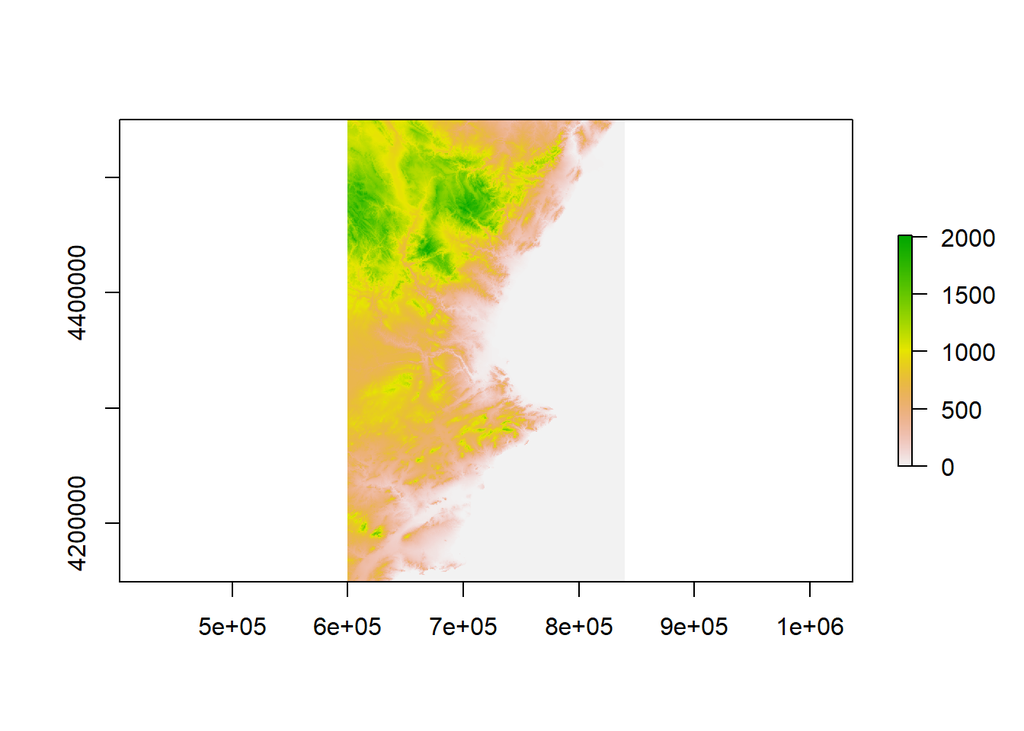

```r
plot(ras)
```

#### Obtaining the predicting locations

In order to obtain a continuous map of precipitation, we need to make punctual predictions in a dense grid of locations. In R there are different ways to define a grid. In this case, we are going to use the DEM’s raster object (‘ras’) above obtained to construct the grid of predicting locations. The collection of pixel mid points make a grid itself, so we just have to extract the mid points and their coordinates of every pixel.

First of all, in order to save computation, the spatial resolution of the raster object can be reduced. Thus, the number of points of the resulting grid will not be so large, and further computation reduced.

Finally, the grid of points will be clipped by the border of CV.

1. Reducing the spatial resolution of the raster. Reduction factor=1/16.

```r
ras <- aggregate(ras, fact=c(4,4), fun=mean)
str(ras)
```

```
## Formal class 'RasterLayer' [package "raster"] with 12 slots
##   ..@ file    :Formal class '.RasterFile' [package "raster"] with 13 slots
##   .. .. ..@ name        : chr ""
##   .. .. ..@ datanotation: chr "FLT4S"
##   .. .. ..@ byteorder   : chr "little"
##   .. .. ..@ nodatavalue : num -Inf
##   .. .. ..@ NAchanged   : logi FALSE
##   .. .. ..@ nbands      : int 1
##   .. .. ..@ bandorder   : chr "BIL"
##   .. .. ..@ offset      : int 0
##   .. .. ..@ toptobottom : logi TRUE
##   .. .. ..@ blockrows   : int 128
##   .. .. ..@ blockcols   : int 128
##   .. .. ..@ driver      : chr ""
##   .. .. ..@ open        : logi FALSE
##   ..@ data    :Formal class '.SingleLayerData' [package "raster"] with 13 slots
##   .. .. ..@ values    : num [1:601601] 805 794 774 743 765 ...
##   .. .. ..@ offset    : num 0
##   .. .. ..@ gain      : num 1
##   .. .. ..@ inmemory  : logi TRUE
##   .. .. ..@ fromdisk  : logi FALSE
##   .. .. ..@ isfactor  : logi FALSE
##   .. .. ..@ attributes: list()
##   .. .. ..@ haveminmax: logi TRUE
##   .. .. ..@ min       : num 0
##   .. .. ..@ max       : num 2003
##   .. .. ..@ band      : int 1
##   .. .. ..@ unit      : chr ""
##   .. .. ..@ names     : chr "mde_100"
##   ..@ legend  :Formal class '.RasterLegend' [package "raster"] with 5 slots
##   .. .. ..@ type      : chr(0)
##   .. .. ..@ values    : logi(0)
##   .. .. ..@ color     : logi(0)
##   .. .. ..@ names     : logi(0)
##   .. .. ..@ colortable: logi(0)
##   ..@ title   : chr(0)
##   ..@ extent  :Formal class 'Extent' [package "raster"] with 4 slots
##   .. .. ..@ xmin: num 6e+05
##   .. .. ..@ xmax: num 840039
##   .. .. ..@ ymin: num 4149546
##   .. .. ..@ ymax: num 4549946
##   ..@ rotated : logi FALSE
##   ..@ rotation:Formal class '.Rotation' [package "raster"] with 2 slots
##   .. .. ..@ geotrans: num(0)
##   .. .. ..@ transfun:function ()
##   ..@ ncols   : int 601
##   ..@ nrows   : int 1001
##   ..@ crs     :Formal class 'CRS' [package "sp"] with 1 slot
##   .. .. ..@ projargs: chr "+proj=utm +zone=30 +ellps=GRS80 +units=m +no_defs"
##   ..@ history : list()
##   ..@ z       : list()
```

2. Converting the raster to a SpatialPoints, thus obtaing the grid of predicting points, stored in the new object ‘loc’.

```r
loc <- rasterToPoints(ras, fun=NULL, spatial=TRUE)
str(loc)
```

```
## Formal class 'SpatialPointsDataFrame' [package "sp"] with 5 slots
##   ..@ data       :'data.frame':  601601 obs. of  1 variable:
##   .. ..$ mde_100: num [1:601601] 805 794 774 743 765 ...
##   ..@ coords.nrs : num(0)
##   ..@ coords     : num [1:601601, 1:2] 599839 600239 600639 601039 601439 ...
##   .. ..- attr(*, "dimnames")=List of 2
##   .. .. ..$ : NULL
##   .. .. ..$ : chr [1:2] "x" "y"
##   ..@ bbox       : num [1:2, 1:2] 599839 4149746 839839 4549746
##   .. ..- attr(*, "dimnames")=List of 2
##   .. .. ..$ : chr [1:2] "x" "y"
##   .. .. ..$ : chr [1:2] "min" "max"
##   ..@ proj4string:Formal class 'CRS' [package "sp"] with 1 slot
##   .. .. ..@ projargs: chr "+proj=utm +zone=30 +ellps=GRS80 +units=m +no_defs"
```

3. Cliping the object ‘loc’ by the VC boundary. The resulting object ‘loc’ will be used as prediction locations.

```r
loc <- crop(loc, lim_cv)
str(loc)
```

```
## Formal class 'SpatialPointsDataFrame' [package "sp"] with 5 slots
##   ..@ data       :'data.frame':  145434 obs. of  1 variable:
##   .. ..$ mde_100: num [1:145434] 747 831 864 848 800 ...
##   ..@ coords.nrs : num(0)
##   ..@ coords     : num [1:145434, 1:2] 739439 738239 738639 739039 739439 ...
##   .. ..- attr(*, "dimnames")=List of 2
##   .. .. ..$ : NULL
##   .. .. ..$ : chr [1:2] "x" "y"
##   ..@ bbox       : num [1:2, 1:2] 627039 4191346 797439 4519346
##   .. ..- attr(*, "dimnames")=List of 2
##   .. .. ..$ : chr [1:2] "x" "y"
##   .. .. ..$ : chr [1:2] "min" "max"
##   ..@ proj4string:Formal class 'CRS' [package "sp"] with 1 slot
##   .. .. ..@ projargs: chr "+proj=utm +zone=30 +ellps=GRS80 +units=m +no_defs"
```

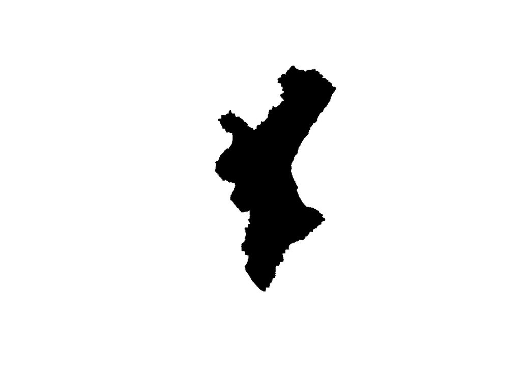

```r
plot(loc)
```

#### Scale and center the coordinates

Due to the fact that when using the library ‘geoR’ to peformm kriging, an numerical inestability error is obtained when data have UTM spatial coordinates, we should first scale the spatial coordinates variables.

```r
media <- colMeans(loc@coords[,]) # Centroid of the object 'loc'
desv <- sd(loc@coords[,]) # Common standard deviation of X and Y coordinates.
```

Scaling the observations

```r
dat@coords <- scale(dat@coords, center= media, scale= c(desv,desv))
str(dat)
```

```
## Formal class 'SpatialPointsDataFrame' [package "sp"] with 5 slots
##   ..@ data       :'data.frame':  212 obs. of  16 variables:
##   .. ..$ INDICATIU : Factor w/ 212 levels "E7029","E7031",..: 1 2 3 4 5 6 7 8 9 10 ...
##   .. ..$ ESTACIO   : Factor w/ 212 levels "AGOST  ESCUELA NACIONAL",..: 173 125 143 109 20 108 93 101 163 80 ...
##   .. ..$ ALTITUD   : int [1:212] 203 2 45 1 40 2 60 502 36 90 ...
##   .. ..$ X         : num [1:212] 680954 693537 695385 701067 695181 ...
##   .. ..$ Y         : num [1:212] 4195707 4184490 4195298 4205830 4211023 ...
##   .. ..$ PROVINCIA : Factor w/ 8 levels "ALBACETE","ALICANTE",..: 5 5 2 2 2 2 2 5 5 5 ...
##   .. ..$ MesosCompl: int [1:212] 549 552 343 552 401 550 402 451 551 477 ...
##   .. ..$ MesosNoCom: int [1:212] 3 0 209 0 151 2 150 101 1 75 ...
##   .. ..$ AnysComple: int [1:212] 43 46 22 46 31 44 28 35 45 36 ...
##   .. ..$ AnysIncomp: int [1:212] 3 0 9 0 4 2 7 3 1 6 ...
##   .. ..$ AnysBuits : int [1:212] 0 0 15 0 11 0 11 8 0 4 ...
##   .. ..$ spring    : num [1:212] 78.9 76.5 74.7 61.9 80 ...
##   .. ..$ summer    : num [1:212] 25 23.8 20.6 17.7 19.8 ...
##   .. ..$ autumn    : num [1:212] 99.6 119.7 109.3 101.6 116.7 ...
##   .. ..$ winter    : num [1:212] 83.6 93.9 89.9 75.4 85 ...
##   .. ..$ annual    : num [1:212] 287 314 295 257 301 ...
##   .. ..- attr(*, "data_types")= chr [1:16] "C" "C" "N" "F" ...
##   ..@ coords.nrs : num(0)
##   ..@ coords     : num [1:212, 1:2] -0.01611 -0.00923 -0.00822 -0.00511 -0.00833 ...
##   .. ..- attr(*, "dimnames")=List of 2
##   .. .. ..$ : chr [1:212] "0" "1" "2" "3" ...
##   .. .. ..$ : chr [1:2] "coords.x1" "coords.x2"
##   .. ..- attr(*, "scaled:center")= Named num [1:2] 710406 4363641
##   .. .. ..- attr(*, "names")= chr [1:2] "x" "y"
##   .. ..- attr(*, "scaled:scale")= num [1:2] 1827640 1827640
##   ..@ bbox       : num [1:2, 1:2] 603884 4184490 814056 4532311
##   .. ..- attr(*, "dimnames")=List of 2
##   .. .. ..$ : chr [1:2] "coords.x1" "coords.x2"
##   .. .. ..$ : chr [1:2] "min" "max"
##   ..@ proj4string:Formal class 'CRS' [package "sp"] with 1 slot
##   .. .. ..@ projargs: chr NA
```

Scaling the predicting locations

```r
loc@coords <- scale(loc@coords, center= media, scale= c(desv,desv))
str(loc)
```

```
## Formal class 'SpatialPointsDataFrame' [package "sp"] with 5 slots
##   ..@ data       :'data.frame':  145434 obs. of  1 variable:
##   .. ..$ mde_100: num [1:145434] 747 831 864 848 800 ...
##   ..@ coords.nrs : num(0)
##   ..@ coords     : num [1:145434, 1:2] 0.0159 0.0152 0.0154 0.0157 0.0159 ...
##   .. ..- attr(*, "dimnames")=List of 2
##   .. .. ..$ : NULL
##   .. .. ..$ : chr [1:2] "x" "y"
##   .. ..- attr(*, "scaled:center")= Named num [1:2] 710406 4363641
##   .. .. ..- attr(*, "names")= chr [1:2] "x" "y"
##   .. ..- attr(*, "scaled:scale")= num [1:2] 1827640 1827640
##   ..@ bbox       : num [1:2, 1:2] 627039 4191346 797439 4519346
##   .. ..- attr(*, "dimnames")=List of 2
##   .. .. ..$ : chr [1:2] "x" "y"
##   .. .. ..$ : chr [1:2] "min" "max"
##   ..@ proj4string:Formal class 'CRS' [package "sp"] with 1 slot
##   .. .. ..@ projargs: chr "+proj=utm +zone=30 +ellps=GRS80 +units=m +no_defs"
```

#### Isotropic (omnidirectional) empiric variogram.

Semivariogram without tendency

```r
svar1 <- variog(coords=dat@coords, data=dat@data$spring, uvec=seq(0,0.19,0.005), trend= "cte")
```

```
## variog: computing omnidirectional variogram
```

```r
str(svar1)
```

```
## List of 20
##  $ u               : num [1:39] 0 0.005 0.01 0.015 0.02 0.025 0.03 0.035 0.04 0.045 ...
##  $ v               : num [1:39] 112 248 351 424 464 ...
##  $ n               : num [1:39] 33 329 602 853 927 ...
##  $ sd              : num [1:39] 360 533 669 773 748 ...
##  $ bins.lim        : num [1:40] 1.00e-12 2.50e-03 7.50e-03 1.25e-02 1.75e-02 ...
##  $ ind.bin         : logi [1:39] TRUE TRUE TRUE TRUE TRUE TRUE ...
##  $ var.mark        : num 1074
##  $ beta.ols        : num 129
##  $ output.type     : chr "bin"
##  $ max.dist        : num 0.192
##  $ estimator.type  : chr "classical"
##  $ n.data          : int 212
##  $ lambda          : num 1
##  $ trend           : chr "cte"
##  $ pairs.min       : num 2
##  $ nugget.tolerance: num 1e-12
##  $ direction       : chr "omnidirectional"
##  $ tolerance       : chr "none"
##  $ uvec            : num [1:39] 0 0.005 0.01 0.015 0.02 0.025 0.03 0.035 0.04 0.045 ...
##  $ call            : language variog(coords = dat@coords, data = dat@data$spring, uvec = seq(0,      0.19, 0.005), trend = "cte")
##  - attr(*, "class")= chr "variogram"
```

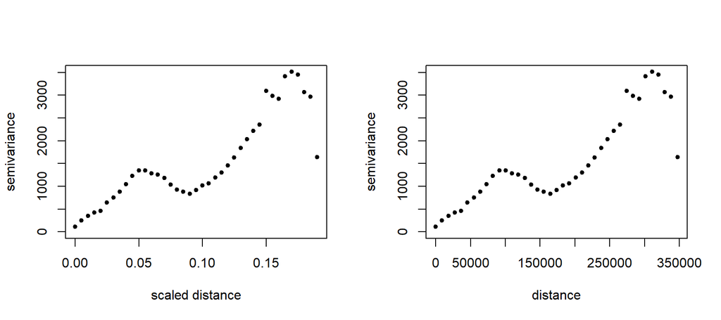

```r
par(mfrow=c(1,2))

# plot semivariogram with standarized distances
plot(svar1, pch=20, cex=1, xlab="scaled distance")

# plot semivariogram with original distances
svar1_undo <- svar1
svar1_undo$u <- svar1$u*desv
plot(svar1_undo, pch=20, cex=1)
```

Semivariagram with tendency

```r
svar2 <- variog(coords=dat@coords, data=dat@data$spring, uvec=seq(0,0.19,0.005), trend= ~dat@coords[,1]*dat@coords[,2]*dat@data$ALTITUD)
```

```
## variog: computing omnidirectional variogram
```

```r
str(svar2)
```

```
## List of 20
##  $ u               : num [1:39] 0 0.005 0.01 0.015 0.02 0.025 0.03 0.035 0.04 0.045 ...
##  $ v               : num [1:39] 105 271 371 417 462 ...
##  $ n               : num [1:39] 33 329 602 853 927 ...
##  $ sd              : num [1:39] 326 577 650 707 690 ...
##  $ bins.lim        : num [1:40] 1.00e-12 2.50e-03 7.50e-03 1.25e-02 1.75e-02 ...
##  $ ind.bin         : logi [1:39] TRUE TRUE TRUE TRUE TRUE TRUE ...
##  $ var.mark        : num 1074
##  $ beta.ols        : Named num [1:8] 1.11e+02 1.58e+03 7.84e+01 4.63e-02 -1.64e+04 ...
##   ..- attr(*, "names")= chr [1:8] "xmat1" "xmat2" "xmat3" "xmat4" ...
##  $ output.type     : chr "bin"
##  $ max.dist        : num 0.192
##  $ estimator.type  : chr "classical"
##  $ n.data          : int 212
##  $ lambda          : num 1
##  $ trend           :Class 'formula'  language ~dat@coords[, 1] * dat@coords[, 2] * dat@data$ALTITUD
##   .. ..- attr(*, ".Environment")=<environment: R_GlobalEnv>
##  $ pairs.min       : num 2
##  $ nugget.tolerance: num 1e-12
##  $ direction       : chr "omnidirectional"
##  $ tolerance       : chr "none"
##  $ uvec            : num [1:39] 0 0.005 0.01 0.015 0.02 0.025 0.03 0.035 0.04 0.045 ...
##  $ call            : language variog(coords = dat@coords, data = dat@data$spring, uvec = seq(0,      0.19, 0.005), trend = ~dat@coords[, 1] * d| __truncated__
##  - attr(*, "class")= chr "variogram"
```

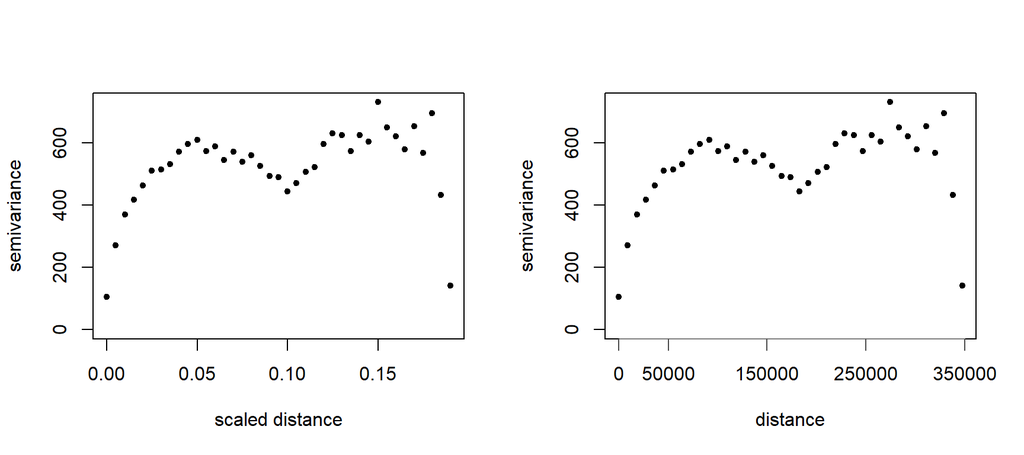

```r
par(mfrow=c(1,2))

plot(svar2, pch=20, cex=1, xlab="scaled distance")

######## plot semivariogram with original distances
plot(svar2, pch=20, cex=1, xaxt="n")
axis(1, at= c(0,50000,150000,250000,350000)/desv, labels= c(0,50000,150000,250000,350000), tick= TRUE, lty= 1, las=1, cex.axis=1, font=1, col=grey(0.5), col.ticks=grey(0.3))
```

### Histogram of distances

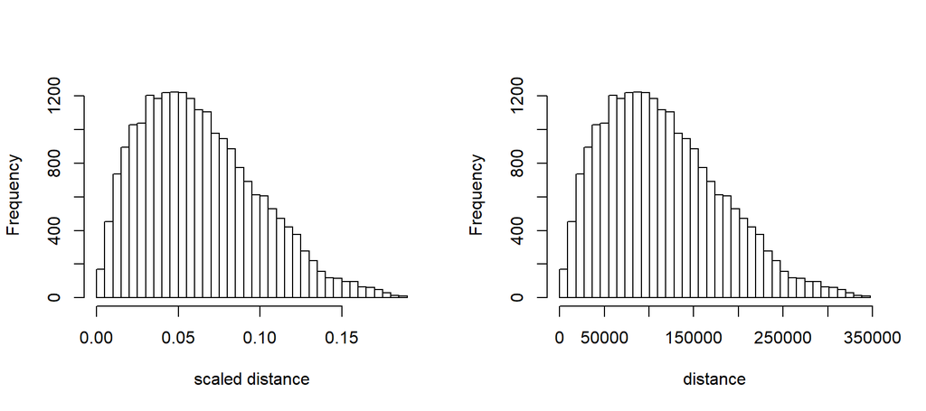

```r
par(mfrow=c(1,2))

distancias <- as.matrix(dist(dat@coords))[upper.tri(as.matrix(dist(dat@coords)), diag=FALSE)]
hist(distancias[distancias<=0.19],breaks=seq(0,0.19,0.005), main="", xlab="scaled distance")

########## Plot with the original distances
distancias_undo <- as.matrix(dist(dat@coords*desv))[upper.tri(as.matrix(dist(dat@coords)), diag=FALSE)]
hist(distancias_undo[distancias_undo<=0.19*desv],breaks=seq(0,0.19*desv,0.005*desv), main="", xlab="distance")
```

#### VARIOGRAM MODEL

##### Adjust of different variogram functions.

```r
sill <- 500
range <- 0.05  # Notice it is in the scaled range
nugget <- 100

par(mfrow=c(1,2))

plot(svar2, xlab="scaled distance")

svar.exp <- variofit(vario=svar2, ini=c(sill, range), cov.model='exponential', fix.nugget=FALSE, nugget=nugget, fix.kappa=FALSE, weights='cressie', minimisation.function='optim', max.dist=0.10)
```

```
## variofit: covariance model used is exponential
## variofit: weights used: cressie
## variofit: minimisation function used: optim
```

```r
lines(svar.exp, lwd=2, col='red')

svar.gau <- variofit(vario=svar2, ini=c(sill, range), cov.model='gaussian', fix.nugget=FALSE, nugget=nugget, weights='cressie', minimisation.function='optim', max.dist=0.10)
```

```
## variofit: covariance model used is gaussian
## variofit: weights used: cressie
## variofit: minimisation function used: optim
```

```r
lines(svar.gau, lwd=2, col='blue')

svar.sph <- variofit(vario=svar2, ini=c(sill, range), cov.model='spherical', fix.nugget=FALSE, nugget=nugget, weights='cressie', minimisation.function='optim', max.dist=0.10)
```

```
## variofit: covariance model used is spherical
## variofit: weights used: cressie
## variofit: minimisation function used: optim
```

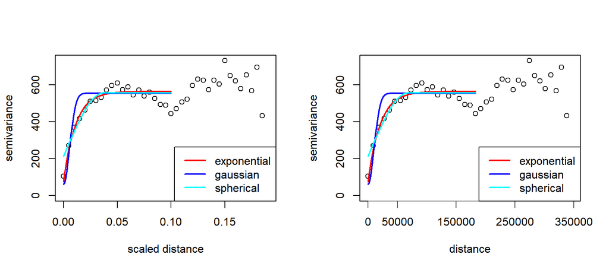

```r
lines(svar.sph, lwd=2, col='cyan')

legend("bottomright", legend= c("exponential","gaussian","spherical"), col = c("red","blue","cyan","pink"), lty= 1, cex=1, lwd=2)

############# Plot with original distances
plot(svar2, xlab="distance", xaxt="n")
lines(svar.exp, lwd=2, col='red')
lines(svar.gau, lwd=2, col='blue')
lines(svar.sph, lwd=2, col='cyan')
axis(1, at= c(0,50000,150000,250000,350000)/desv, labels= c(0,50000,150000,250000,350000), tick= TRUE, lty= 1, las=1, cex.axis=1, font=1, col=grey(0.5), col.ticks=grey(0.3))

legend("bottomright", legend= c("exponential","gaussian","spherical"), col = c("red","blue","cyan","pink"), lty= 1, cex=1, lwd=2)
```

#### Kriging adjustment

Adjustment of Kriging model

```r
uk <- krige.conv(data=dat@data$spring, coords=dat@coords, locations= loc@coords, krige= krige.control(type.krige = "ok", trend.d= trend.spatial( ~dat@coords[,1]*dat@coords[,2]*dat@data$ALTITUD ), trend.l= trend.spatial( ~loc@coords[,1]*loc@coords[,2]*loc@data$mde_100 ), obj.model= svar.exp))
```

```
## krige.conv: model with covariates matrix provided by the user
## krige.conv: Kriging performed using global neighbourhood
```

```r
str(uk)
```

```
## List of 6
##  $ predict     : num [1:145434] 139 141 142 142 141 ...
##  $ krige.var   : num [1:145434] 299 304 309 308 304 ...
##  $ beta.est    : Named num [1:8] 1.10e+02 6.45e+02 1.74e+02 4.27e-02 -7.05e+03 ...
##   ..- attr(*, "names")= chr [1:8] "beta0" "beta1" "beta2" "beta3" ...
##  $ distribution: chr "normal"
##  $ message     : chr "krige.conv: Kriging performed using global neighbourhood"
##  $ call        : language krige.conv(coords = dat@coords, data = dat@data$spring, locations = loc@coords,      krige = krige.control(type.k| __truncated__ ...
##  - attr(*, "sp.dim")= chr "2d"
##  - attr(*, "prediction.locations")= language loc@coords
##  - attr(*, "parent.env")=<environment: R_GlobalEnv>
##  - attr(*, "data.locations")= language dat@coords
##  - attr(*, "class")= chr "kriging"
```

Adding kriging outcomes to the object ‘loc’

```r
loc@data$predict <- uk$predict  # predictions
loc@data$predict.sd <- sqrt(uk$krige.var)  # prediction error
```

#### Cross-validation (CV) model assesment

```r
for(i in 1:212){

uk_vc <- krige.conv(data= dat@data$spring[-i], coords= dat@coords[-i,], locations= dat@coords[i,], borders= NULL, krige= krige.control(type.krige= "ok", trend.d= trend.spatial( ~dat@coords[-i,1]*dat@coords[-i,2]*dat@data$ALTITUD[-i]), trend.l= trend.spatial( ~dat@coords[i,1]*dat@coords[i,2]*dat@data$ALTITUD[i]), obj.model= svar.exp))

    dat@data$predict.cv[i] <- uk_vc$predict
    dat@data$predict.cv.sd[i] <- sqrt(uk_vc$krige.var)
}
```

Computing Cross-validation (CV) residuals

```r
dat@data$res.cv <- dat@data$spring[] - dat@data$predict.cv

str(dat)
```

```
## Formal class 'SpatialPointsDataFrame' [package "sp"] with 5 slots
##   ..@ data       :'data.frame':  212 obs. of  19 variables:
##   .. ..$ INDICATIU    : Factor w/ 212 levels "E7029","E7031",..: 1 2 3 4 5 6 7 8 9 10 ...
##   .. ..$ ESTACIO      : Factor w/ 212 levels "AGOST  ESCUELA NACIONAL",..: 173 125 143 109 20 108 93 101 163 80 ...
##   .. ..$ ALTITUD      : int [1:212] 203 2 45 1 40 2 60 502 36 90 ...
##   .. ..$ X            : num [1:212] 680954 693537 695385 701067 695181 ...
##   .. ..$ Y            : num [1:212] 4195707 4184490 4195298 4205830 4211023 ...
##   .. ..$ PROVINCIA    : Factor w/ 8 levels "ALBACETE","ALICANTE",..: 5 5 2 2 2 2 2 5 5 5 ...
##   .. ..$ MesosCompl   : int [1:212] 549 552 343 552 401 550 402 451 551 477 ...
##   .. ..$ MesosNoCom   : int [1:212] 3 0 209 0 151 2 150 101 1 75 ...
##   .. ..$ AnysComple   : int [1:212] 43 46 22 46 31 44 28 35 45 36 ...
##   .. ..$ AnysIncomp   : int [1:212] 3 0 9 0 4 2 7 3 1 6 ...
##   .. ..$ AnysBuits    : int [1:212] 0 0 15 0 11 0 11 8 0 4 ...
##   .. ..$ spring       : num [1:212] 78.9 76.5 74.7 61.9 80 ...
##   .. ..$ summer       : num [1:212] 25 23.8 20.6 17.7 19.8 ...
##   .. ..$ autumn       : num [1:212] 99.6 119.7 109.3 101.6 116.7 ...
##   .. ..$ winter       : num [1:212] 83.6 93.9 89.9 75.4 85 ...
##   .. ..$ annual       : num [1:212] 287 314 295 257 301 ...
##   .. ..$ predict.cv   : num [1:212] 83.7 73.4 75.3 72.7 70.4 ...
##   .. ..$ predict.cv.sd: num [1:212] 20.4 21 18.1 16.7 15.9 ...
##   .. ..$ res.cv       : num [1:212] -4.73 3.06 -0.6 -10.8 9.58 ...
##   .. ..- attr(*, "data_types")= chr [1:16] "C" "C" "N" "F" ...
##   ..@ coords.nrs : num(0)
##   ..@ coords     : num [1:212, 1:2] -0.01611 -0.00923 -0.00822 -0.00511 -0.00833 ...
##   .. ..- attr(*, "dimnames")=List of 2
##   .. .. ..$ : chr [1:212] "0" "1" "2" "3" ...
##   .. .. ..$ : chr [1:2] "coords.x1" "coords.x2"
##   .. ..- attr(*, "scaled:center")= Named num [1:2] 710406 4363641
##   .. .. ..- attr(*, "names")= chr [1:2] "x" "y"
##   .. ..- attr(*, "scaled:scale")= num [1:2] 1827640 1827640
##   ..@ bbox       : num [1:2, 1:2] 603884 4184490 814056 4532311
##   .. ..- attr(*, "dimnames")=List of 2
##   .. .. ..$ : chr [1:2] "coords.x1" "coords.x2"
##   .. .. ..$ : chr [1:2] "min" "max"
##   ..@ proj4string:Formal class 'CRS' [package "sp"] with 1 slot
##   .. .. ..@ projargs: chr NA
```

Diagnosis plots

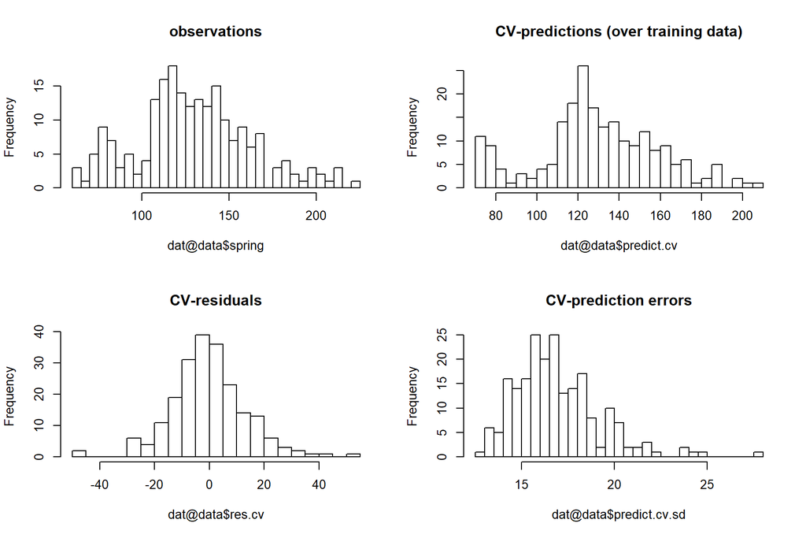

```r
# Histogram of the cross-validation
par(mfrow=c(2,2))
hist(dat@data$spring, breaks=30, main="observations")
hist(dat@data$predict.cv, breaks=30, main="CV-predictions (over training data)")
hist(dat@data$res.cv, breaks=30, main="CV-residuals")
hist(dat@data$predict.cv.sd, breaks=30, main="CV-prediction errors")
```

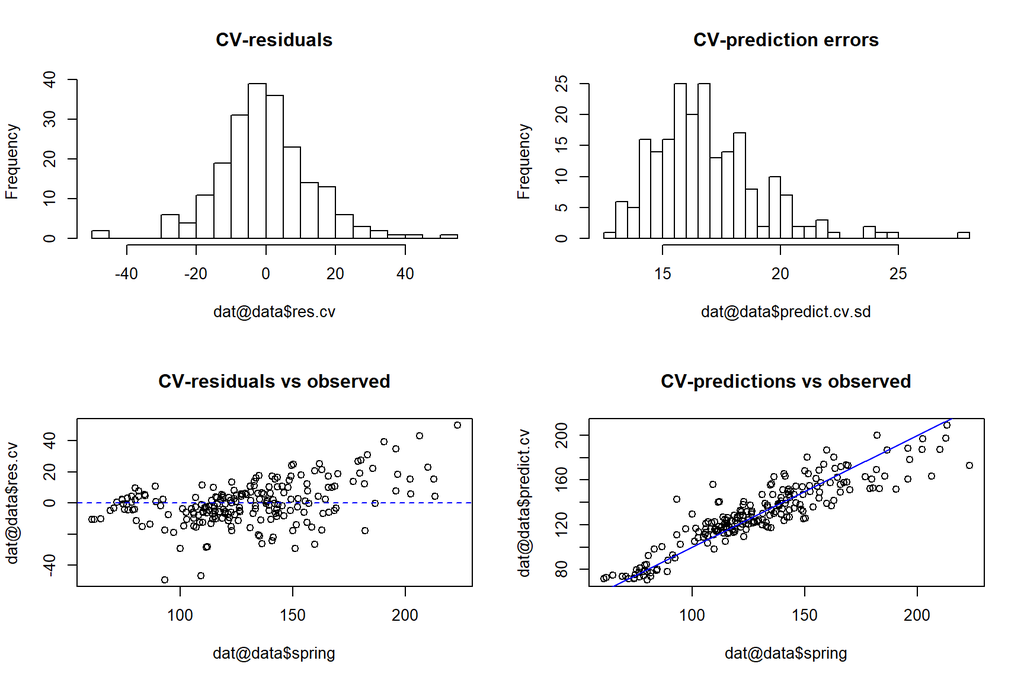

```r
# Diagnosis plots
par(mfrow=c(2,2))
hist(dat@data$res.cv, breaks=30, main="CV-residuals")
hist(dat@data$predict.cv.sd, breaks=30, main="CV-prediction errors")
plot(dat@data$spring, dat@data$res.cv, main="CV-residuals vs observed")
abline(h=0, col="blue", lty=2)
plot(dat@data$spring, dat@data$predict.cv, main="CV-predictions vs observed")
abline(a=0, b=1, col="blue", lty=1, lwd=1)
```

Identifying outliers

```r
dat@data[ dat@data$res.cv < -40 | dat@data$res.cv > 25 , c(1:2,12:19)]
```

```
##     INDICATIU                   ESTACIO spring summer autumn winter annual
## 43     E8039A        TARBENA  C H JUCAR 223.14  49.58 269.07 273.81 815.60
## 45     E8040I      EMBALSE DE GUADALEST 180.16  52.17 251.40 238.49 722.21
## 64      E8076 BENIFAIRO DE LA VALLDIGNA 183.07  65.69 292.72 224.06 765.54
## 75      E8216                TEJADILLOS 195.72 111.09 204.18 218.77 729.77
## 85      E8271          ENGUERA LA MATEA 161.91  61.62 177.25 163.72 564.49
## 90      E8282                 BOCAIRENT 179.04  61.33 195.37 184.25 619.99
## 94      E8287                 CARRICOLA 190.63  55.13 223.17 216.62 685.56
## 172    E8472E                  BARRACAS  93.26  47.73 102.74  72.93 316.67
## 209     E9979          MAS DE BARBERANS 206.40 114.99 275.59 161.97 758.95
## 211    E9987O     AMPOSTA 'ERMS SALATS' 109.35  75.14 200.77 109.39 494.65
##     predict.cv predict.cv.sd    res.cv
## 43    173.0955      15.79919  50.04452
## 45    152.8507      16.03189  27.30933
## 64    152.0424      18.25450  31.02761
## 75    160.8793      19.61078  34.84070
## 85    136.9088      18.75741  25.00116
## 90    152.4696      15.83391  26.57040
## 94    151.5626      15.98182  39.06739
## 172   142.9432      15.82148 -49.68319
## 209   163.4472      19.51733  42.95279
## 211   156.1062      27.95603 -46.75618
```

#### Undo the scaling of the spatial coordinates

```r
loc@coords <- scale(loc@coords, center=FALSE, scale= 1/c(desv,desv))
loc@coords <- scale(loc@coords, center= -1*media, scale=FALSE)

dat@coords <- scale(dat@coords, center=FALSE, scale= 1/c(desv,desv))
dat@coords <- scale(dat@coords, center= -1*media, scale=FALSE)
```

#### Map of the kriging predictions

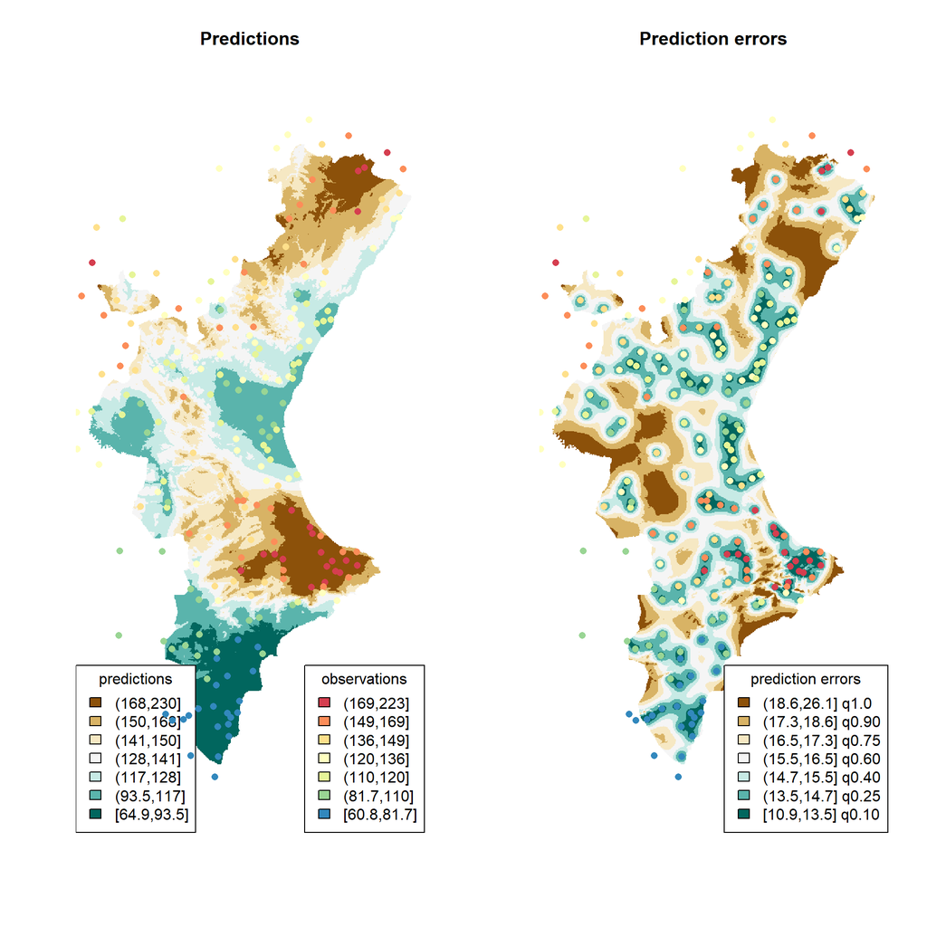

```r
par(mfrow=c(1,2))

# Predictions.
loc1_predict <- SpatialPixelsDataFrame(loc@coords, data=as.data.frame(loc@data$predict))

q2 <- quantile(loc1_predict@data[,1], c(0,0.10,0.25,0.40,0.60,0.75,0.90,1))
image(loc1_predict, col=brewer.pal(7,"BrBG")[7:1], asp=1, breaks=q2, main="Predictions")

# Legend.
br2 <- cut(loc1_predict@data[,1], breaks=q2, include.lowest=TRUE)
legend("bottomleft", legend=levels(br2)[7:1], fill=brewer.pal(7,"BrBG")[1:7], title= "predictions", cex=1)

# Observed data.
q3 <- quantile(dat@data$spring[], c(0,0.10,0.25,0.40,0.60,0.75,0.90,1))
br3 <- cut(dat@data$spring[], breaks=q3, include.lowest=TRUE)
points(dat@coords[,1], dat@coords[,2], col=brewer.pal(7,"Spectral")[7:1][br3], asp=1, pch=16)
legend("bottomright", legend=levels(br3)[7:1], fill=brewer.pal(7,"Spectral")[1:7], title= "observations", cex=1)


# Predicting errors.
loc1_predict.sd <- SpatialPixelsDataFrame(loc@coords, data=as.data.frame(loc@data$predict.sd))

q4 <- quantile(loc1_predict.sd@data[,1], c(0,0.10,0.25,0.40,0.60,0.75,0.90,1))
image(loc1_predict.sd, col=brewer.pal(7,"BrBG")[7:1], asp=1, breaks=q4, main="Prediction errors")

# Legend.
br4 <- cut(loc1_predict.sd@data[,1], breaks=q4, include.lowest=TRUE)
legend("bottomright", legend=paste(levels(br4)[7:1],c("q0.10","q0.25","q0.40","q0.60","q0.75","q0.90","q1.0")[7:1]), fill=brewer.pal(7,"BrBG")[1:7], title= "prediction errors", cex=1)

# Observed data.
points(dat@coords[,1], dat@coords[,2], col=brewer.pal(7,"Spectral")[7:1][br3], asp=1, pch=16)
```